# Storm analysis

Sabine D’Amico

November 7, 2018

## Public health and economic impacts from storms and other severe weather patterns

# This analysis examines fatalities and injuries and economic damages resulting # from storms and other

#severe weather patterns in the USA since 1950. The starting point for the analysis is the Storm dataset # from U.S. National Oceanic and Atmospheric Administration’s (NOAA) with subsequent transformation of # the data to examine two fundamental questions: # 1. Across the United States, which types of events (as indicated in the EVTYPE variable) are most harmful with respect # to population health? # 2. Across the United States, which types of events have the greatest economic consequences? # I found that Tornados were the leading cause of injuries and fatalities whereas Flood events were the # leading cause of property and crop damage. # Tornadoes caused 31,893 death and injuries whereas floods caused property and crop damage in access of # $140B in damage.

# The U.S. National Oceanic and Atmospheric Administration’s (NOAA) is found at this site:

```r
FileURL <- "https://d396qusza40orc.cloudfront.net/repdata%2Fdata%2FStormData.csv.bz2"
```

# The file is downloaded:

```r
download.file(FileURL, destfile = "~./R/data/FStormdata.csv.bz2")
```

# The downloaded file is being read:

```r
Stormdata <- read.csv("~./R/data/FStormdata.csv.bz2")
```

# Transform into data.frame

```r
Stormdata <-data.frame(Stormdata)
```

# Examine data

```r
summary(Stormdata)
```

```
##     STATE__                  BGN_DATE             BGN_TIME
##  Min.   : 1.0   5/25/2011 0:00:00:  1202   12:00:00 AM: 10163
##  1st Qu.:19.0   4/27/2011 0:00:00:  1193   06:00:00 PM:  7350
##  Median :30.0   6/9/2011 0:00:00 :  1030   04:00:00 PM:  7261
##  Mean   :31.2   5/30/2004 0:00:00:  1016   05:00:00 PM:  6891
##  3rd Qu.:45.0   4/4/2011 0:00:00 :  1009   12:00:00 PM:  6703
##  Max.   :95.0   4/2/2006 0:00:00 :   981   03:00:00 PM:  6700
##                 (Other)          :895866   (Other)    :857229
##    TIME_ZONE          COUNTY           COUNTYNAME         STATE
##  CST    :547493   Min.   :  0.0   JEFFERSON :  7840   TX     : 83728
##  EST    :245558   1st Qu.: 31.0   WASHINGTON:  7603   KS     : 53440
##  MST    : 68390   Median : 75.0   JACKSON   :  6660   OK     : 46802
##  PST    : 28302   Mean   :100.6   FRANKLIN  :  6256   MO     : 35648
##  AST    :  6360   3rd Qu.:131.0   LINCOLN   :  5937   IA     : 31069
##  HST    :  2563   Max.   :873.0   MADISON   :  5632   NE     : 30271
##  (Other):  3631                   (Other)   :862369   (Other):621339
##                EVTYPE         BGN_RANGE           BGN_AZI
##  HAIL             :288661   Min.   :   0.000          :547332
##  TSTM WIND        :219940   1st Qu.:   0.000   N      : 86752
##  THUNDERSTORM WIND: 82563   Median :   0.000   W      : 38446
##  TORNADO          : 60652   Mean   :   1.484   S      : 37558
##  FLASH FLOOD      : 54277   3rd Qu.:   1.000   E      : 33178
##  FLOOD            : 25326   Max.   :3749.000   NW     : 24041
##  (Other)          :170878                      (Other):134990
##          BGN_LOCATI                  END_DATE             END_TIME
##               :287743                    :243411              :238978
##  COUNTYWIDE   : 19680   4/27/2011 0:00:00:  1214   06:00:00 PM:  9802
##  Countywide   :   993   5/25/2011 0:00:00:  1196   05:00:00 PM:  8314
##  SPRINGFIELD  :   843   6/9/2011 0:00:00 :  1021   04:00:00 PM:  8104
##  SOUTH PORTION:   810   4/4/2011 0:00:00 :  1007   12:00:00 PM:  7483
##  NORTH PORTION:   784   5/30/2004 0:00:00:   998   11:59:00 PM:  7184
##  (Other)      :591444   (Other)          :653450   (Other)    :622432
##    COUNTY_END COUNTYENDN       END_RANGE           END_AZI
##  Min.   :0    Mode:logical   Min.   :  0.0000          :724837
##  1st Qu.:0    NA's:902297    1st Qu.:  0.0000   N      : 28082
##  Median :0                   Median :  0.0000   S      : 22510
##  Mean   :0                   Mean   :  0.9862   W      : 20119
##  3rd Qu.:0                   3rd Qu.:  0.0000   E      : 20047
##  Max.   :0                   Max.   :925.0000   NE     : 14606
##                                                 (Other): 72096
```

[output cut: 41 more lines]

```
##  Min.   :   0   Min.   :-14451   Min.   :   0   Min.   :-14455
##  1st Qu.:2802   1st Qu.:  7247   1st Qu.:   0   1st Qu.:     0
##  Median :3540   Median :  8707   Median :   0   Median :     0
##  Mean   :2875   Mean   :  6940   Mean   :1452   Mean   :  3509
##  3rd Qu.:4019   3rd Qu.:  9605   3rd Qu.:3549   3rd Qu.:  8735
##  Max.   :9706   Max.   : 17124   Max.   :9706   Max.   :106220
##  NA's   :47                      NA's   :40
##                                            REMARKS           REFNUM
##                                                :287433   Min.   :     1
##                                                : 24013   1st Qu.:225575
##  Trees down.\n                                 :  1110   Median :451149
##  Several trees were blown down.\n              :   568   Mean   :451149
##  Trees were downed.\n                          :   446   3rd Qu.:676723
##  Large trees and power lines were blown down.\n:   432   Max.   :902297
##  (Other)                                       :588295
```

```r
head((Stormdata))
```

```
##   STATE__           BGN_DATE BGN_TIME TIME_ZONE COUNTY COUNTYNAME STATE
## 1       1  4/18/1950 0:00:00     0130       CST     97     MOBILE    AL
## 2       1  4/18/1950 0:00:00     0145       CST      3    BALDWIN    AL
## 3       1  2/20/1951 0:00:00     1600       CST     57    FAYETTE    AL
## 4       1   6/8/1951 0:00:00     0900       CST     89    MADISON    AL
## 5       1 11/15/1951 0:00:00     1500       CST     43    CULLMAN    AL
## 6       1 11/15/1951 0:00:00     2000       CST     77 LAUDERDALE    AL
##    EVTYPE BGN_RANGE BGN_AZI BGN_LOCATI END_DATE END_TIME COUNTY_END
## 1 TORNADO         0                                               0
## 2 TORNADO         0                                               0
## 3 TORNADO         0                                               0
## 4 TORNADO         0                                               0
## 5 TORNADO         0                                               0
## 6 TORNADO         0                                               0
##   COUNTYENDN END_RANGE END_AZI END_LOCATI LENGTH WIDTH F MAG FATALITIES
```

[output cut: 20 more lines]

```r
str(Stormdata$PROPDMGEXP)
```

```
##  Factor w/ 19 levels "","-","?","+",..: 17 17 17 17 17 17 17 17 17 17 ...
```

# Install packages

```r
library(dplyr)
```

```r
library(ggplot2)
```

## Examine what type of events have a significant impact on injuries and fatalities

```r
PopulationImpact <- select(Stormdata,EVTYPE,FATALITIES,INJURIES) %>%
        group_by(EVTYPE)
PopulationImpact <- aggregate(FATALITIES ~ EVTYPE + INJURIES, PopulationImpact, sum)
arrange(PopulationImpact, EVTYPE) %>%
        group_by(EVTYPE) %>%
        tally()
```

```
## # A tibble: 985 x 2
##    EVTYPE                      n
##    <fct>                   <int>
##  1 "   HIGH SURF ADVISORY"     1
##  2 " COASTAL FLOOD"            1
##  3 " FLASH FLOOD"              1
##  4 " LIGHTNING"                1
##  5 " TSTM WIND"                1
##  6 " TSTM WIND (G45)"          1
##  7 " WATERSPOUT"               1
##  8 " WIND"                     1
##  9 ?                           1
## 10 ABNORMAL WARMTH             1
## # ... with 975 more rows
```

```r
TotalIMP <- PopulationImpact$INJURIES + PopulationImpact$FATALITIES
TotalPopImpact <- cbind(PopulationImpact,TotalIMP)
TotalPopImpact1 <- arrange(TotalPopImpact,EVTYPE)
TotalPopImpact2 <- group_by(TotalPopImpact1,EVTYPE)
TotalPopImpact3 <- aggregate(TotalIMP ~ EVTYPE, TotalPopImpact2, sum)
TotalPopImpact4 <- filter(TotalPopImpact3, TotalIMP > 1000)
TotalPopImpact5 <- arrange(TotalPopImpact4,desc(TotalIMP))
```

##Results

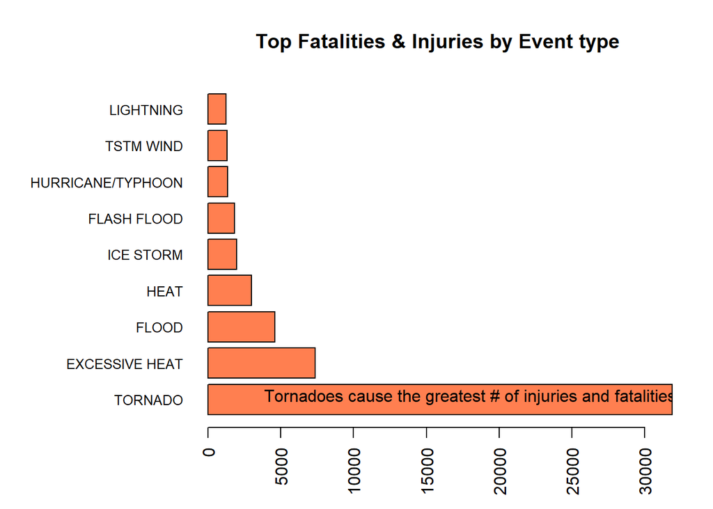

```r
par(las=2)
par(mar=c(4,10,4,2))
barplot(TotalPopImpact5$TotalIMP, main="Top Fatalities & Injuries by Event type", horiz=TRUE,
        names.arg = TotalPopImpact5$EVTYPE, cex.names = 0.8, border = "black", col = "coral")
text(18000,0.8,"Tornadoes cause the greatest # of injuries and fatalities")
```

# Tornadoes are the leading cause of injuries and fatalities: 31,893 cases since 1950

## Examine what events have the greatest economic impact by looking at the estimated property damage

```r
PropCropDmg <- select(Stormdata, EVTYPE,CROPDMG,PROPDMG,CROPDMGEXP,PROPDMGEXP) %>%
        group_by(EVTYPE)
summary(PropCropDmg$CROPDMGEXP)
```

```
##             ?      0      2      B      k      K      m      M
## 618413      7     19      1      9     21 281832      1   1994
```

```r
summary(PropCropDmg$PROPDMGEXP)
```

```
##             -      ?      +      0      1      2      3      4      5
## 465934      1      8      5    216     25     13      4      4     28
##      6      7      8      B      h      H      K      m      M
##      4      5      1     40      1      6 424665      7  11330
```

```r
PropCropDmg$PROPDMGEXP <- sub("[-?+012345678]", "1", PropCropDmg$PROPDMGEXP, ignore.case = TRUE)
PropCropDmg$PROPDMGEXP <- sub("^$", "1", PropCropDmg$PROPDMGEXP, ignore.case = TRUE)
PropCropDmg$PROPDMGEXP <- sub("K", "1000", PropCropDmg$PROPDMGEXP, ignore.case = TRUE)
PropCropDmg$PROPDMGEXP <- sub("M", "1000000", PropCropDmg$PROPDMGEXP, ignore.case = TRUE)
PropCropDmg$PROPDMGEXP <- sub("B", "1000000000", PropCropDmg$PROPDMGEXP, ignore.case = TRUE)
PropCropDmg$PROPDMGEXP <- sub("H", "100", PropCropDmg$PROPDMGEXP, ignore.case = TRUE)
PropCropDmg$TotalPropdmg <- PropCropDmg$PROPDMG*as.numeric(PropCropDmg$PROPDMGEXP)


PropCropDmg$CROPDMGEXP <- sub("[?02]", "1", PropCropDmg$CROPDMGEXP, ignore.case = TRUE)
PropCropDmg$CROPDMGEXP <- sub("^$", "1", PropCropDmg$CROPDMGEXP, ignore.case = TRUE)
PropCropDmg$CROPDMGEXP <- sub("^K$", "1000", PropCropDmg$CROPDMGEXP, ignore.case = TRUE)
PropCropDmg$CROPDMGEXP <- sub("^M$", "1000000", PropCropDmg$CROPDMGEXP, ignore.case = TRUE)
PropCropDmg$CROPDMGEXP <- sub("^B$", "1000000000", PropCropDmg$CROPDMGEXP, ignore.case = TRUE)
PropCropDmg$TotalCropdmg <- PropCropDmg$CROPDMG*as.numeric(PropCropDmg$CROPDMGEXP)
PropCropDmg$TotalDMG <- PropCropDmg$TotalCropdmg+PropCropDmg$TotalPropdmg

PropCropDmg <- select(PropCropDmg,EVTYPE,TotalDMG) %>%
        arrange(PropCropDmg$EVTYPE)
PropCropDmg1 <- data.frame(PropCropDmg)
PropCropDmg2 <- aggregate(TotalDMG ~ EVTYPE, PropCropDmg1,sum)
PropCropDmg3 <- filter(PropCropDmg2, TotalDMG > 5000000000)
PropCropDmg4 <- arrange(PropCropDmg3,desc(TotalDMG))
PropCropDmg4$TotalDMG <- PropCropDmg4$TotalDMG/1000000000
```

##Results

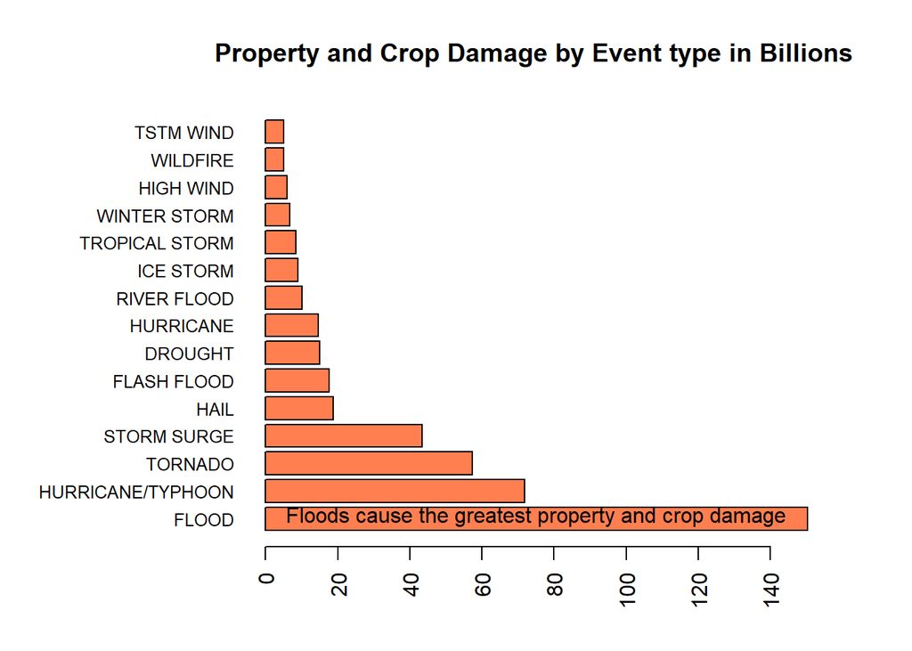

```r
par(las=2)
par(mar=c(4,10,4,4))
barplot(PropCropDmg4$TotalDMG, main="Property and Crop Damage by Event type in Billions", horiz=TRUE,
        names.arg = PropCropDmg4$EVTYPE, cex.names = 0.8, border = "black", col = "coral")
text(75,0.8,"Floods cause the greatest property and crop damage")
```

#Floods are the leading cause of property and crop damage with over $140B in damages.